# Retail Business Performace & Profitability Analysis

# Connection

```python
# DB connection
conn = mysql.connector.connect(
    host="127.0.0.1",
    user="root",
    port=3306,
    password="admin",
    database="Retail"
 )


engine = create_engine("mysql+mysqlconnector://root:admin@127.0.0.1:3306/Retail")

# Helper
def run_query(query):
    return pd.read_sql(query, conn)
```

# Visualizations

### Payment Method Distribution

This chart shows how many transactions were completed using each payment method.  
It helps us identify the most preferred payment modes by customers.

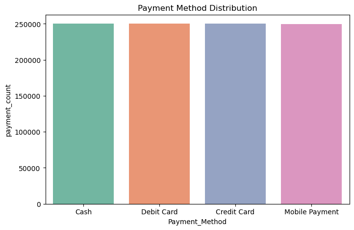

```python
df = run_query("""
SELECT Payment_Method, COUNT(Payment_Method) AS payment_count
FROM retail_dataset
GROUP BY Payment_Method
ORDER BY payment_count DESC;
""")

plt.figure(figsize=(8,5))
sns.barplot(x="Payment_Method", y="payment_count", data=df, palette="Set2")
plt.title("Payment Method Distribution")
plt.show()
```

### Payment Methods by City

This grouped bar chart compares the usage of different payment methods across cities.  
It highlights regional variations in customer payment preferences.

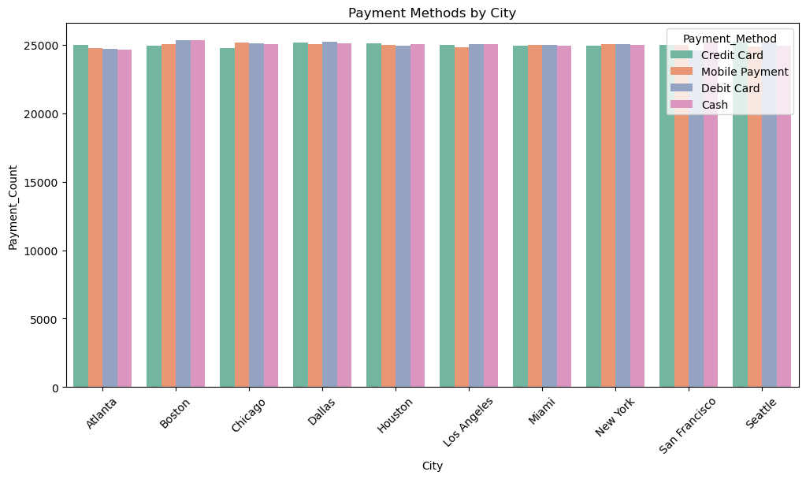

```python
df = run_query("""
SELECT City, Payment_Method, COUNT(Payment_Method) AS Payment_Count
FROM retail_dataset
GROUP BY Payment_Method, City
ORDER BY City, Payment_Count DESC;
""")

plt.figure(figsize=(12,6))
sns.barplot(x="City", y="Payment_Count", hue="Payment_Method", data=df, palette="Set2")
plt.title("Payment Methods by City")
plt.xticks(rotation=45)
plt.show()
```

### Top Product by Store Type

This bar chart highlights the single most sold product within each store type.  
It reveals which products are the top drivers of sales depending on the store category.

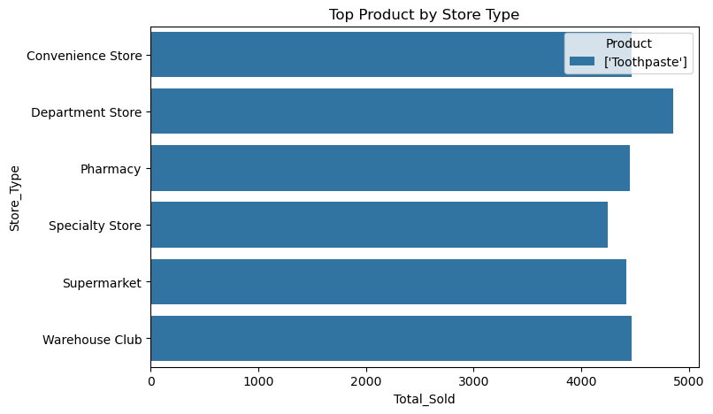

```python
df = run_query("""
SELECT Store_Type, Product, Total_Sold FROM (
    SELECT Store_Type, Product, SUM(Total_Items) AS Total_Sold,
           ROW_NUMBER() OVER (PARTITION BY Store_Type ORDER BY SUM(Total_Items) DESC) AS rn
    FROM retail_dataset
    GROUP BY Store_Type, Product
) ranked
WHERE rn = 1;
""")
plt.figure(figsize=(8,5))
sns.barplot(x="Total_Sold", y="Store_Type", hue="Product", data=df, dodge=False)
plt.title("Top Product by Store Type")
plt.show()
```

### Yearly Sales (Items vs. Cost)

This line chart shows the trend of items sold and total revenue over time, year by year.  
It helps us understand sales growth, seasonal dips, or upward/downward trends.

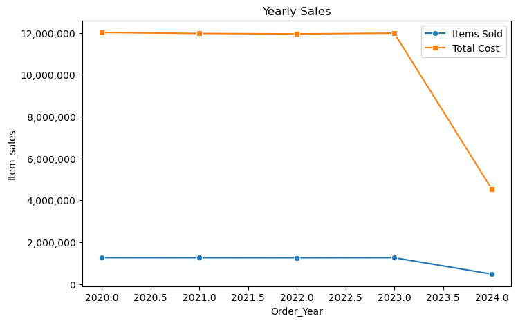

```python
df = run_query("""
SELECT YEAR(Order_Date) AS Order_Year, SUM(Total_Items) AS Item_sales,
       ROUND(SUM(Total_Cost),2) AS Item_cost
FROM retail_dataset
GROUP BY Order_Year
ORDER BY Order_Year;
""")
plt.figure(figsize=(8,5))
sns.lineplot(x="Order_Year", y="Item_sales", data=df, marker="o", label="Items Sold")
sns.lineplot(x="Order_Year", y="Item_cost", data=df, marker="s", label="Total Cost")
plt.title("Yearly Sales")
plt.gca().yaxis.set_major_formatter(ticker.FuncFormatter(lambda x, pos: f'{int(x):,}'))
plt.legend()
plt.show()
```

### Season-wise Sales per Year

This grouped bar chart breaks down total sales by season for each year.  
It shows which seasons contribute the most to yearly sales and seasonal shopping patterns.

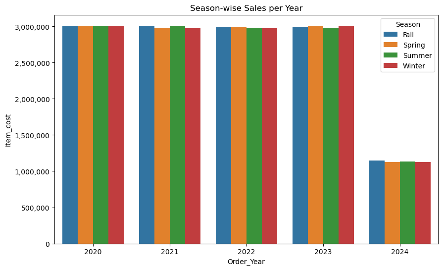

```python
df = run_query("""
SELECT YEAR(Order_Date) AS Order_Year, Season, ROUND(SUM(Total_Cost),2) AS Item_cost
FROM retail_dataset
GROUP BY Order_Year, Season
ORDER BY Order_Year;
""")
plt.figure(figsize=(10,6))
sns.barplot(x="Order_Year", y="Item_cost", hue="Season", data=df)
plt.title("Season-wise Sales per Year")
plt.gca().yaxis.set_major_formatter(ticker.FuncFormatter(lambda x, pos: f'{int(x):,}'))
plt.show()
```